# Food Desert Analysis in Wake County, NC

Author

Your Name

Published

March 8, 2026

# 1 Introduction

The Wake County Department of Health and Human Services administers the Supplemental Nutrition Assistance Program (SNAP) and the Special Supplemental Nutrition Program for Women, Infants, and Children (WIC) — programs collectively designed to help low-income residents purchase nutritious food. A critical concern, however, is that recipients may not have convenient access to healthy food retailers, regardless of the financial support they receive. This phenomenon — whereby geographic barriers limit access to affordable, nutritious food — is commonly called a **food desert**.

Definitions of food deserts vary across policy contexts, but they generally share a common thread: they are areas where residents face difficulty accessing supermarkets or grocery stores, particularly when compounded by low income or lack of vehicle access (Annie E. Casey Foundation, 2021). The United States Department of Agriculture (USDA) defines a food desert in urban areas as a low-income census tract where more than one-third of residents live more than one mile from the nearest supermarket.

For this analysis, we adopt a simplified but well-grounded definition: **any area located more than 1 mile (1,609 meters) from a supermarket is considered a food desert**. Using spatial data from OpenStreetMap, U.S. Census Bureau block group geometries, and demographic data, this report (1) maps food deserts across Wake County, (2) analyzes the demographic characteristics of food desert residents, and (3) recommends a location for a new subsidized supermarket.

```r
# Auto-install any missing packages
required_pkgs <- c("sf", "dplyr", "ggplot2", "tidyr", "readr", "scales", "patchwork")
missing_pkgs  <- required_pkgs[!required_pkgs %in% installed.packages()[, "Package"]]
if (length(missing_pkgs) > 0) {
  install.packages(missing_pkgs, repos = "https://cloud.r-project.org")
}

library(sf)
library(dplyr)
library(ggplot2)
library(tidyr)
library(readr)
library(scales)
library(patchwork)

# NC State Plane NAD83(2011) — EPSG 6543, units = metres
NC_CRS <- 6543

desert_colors <- c("Food Desert" = "#d73027", "Not a Food Desert" = "#91bfdb")
```

# 2 Data

The analysis draws on three datasets provided for this assignment, all located in the same directory as this document:

1. **`triangle_supermarkets_osm.shp`** — point locations of supermarkets in the Triangle region, from OpenStreetMap.
2. **`orange_durham_wake_block_groups.shp`** — Census block group polygons for Wake, Orange, and Durham counties.
3. **`triangle_census.csv`** — demographic data per block group including total population, households, race, vehicle access, and income.

```r
# ── Grocery / supermarket locations ──────────────────────────────────────────
grocery <- st_read("triangle_supermarkets_osm.shp", quiet = TRUE)
cat("Supermarkets loaded:", nrow(grocery), "features\n")
```

```
Supermarkets loaded: 208 features
```

```r
cat("CRS:", st_crs(grocery)$input, "\n\n")
```

```
CRS: WGS 84
```

```r
# ── Block group geometries ────────────────────────────────────────────────────
block_groups_raw <- st_read("orange_durham_wake_block_groups.shp", quiet = TRUE)
cat("Block groups loaded:", nrow(block_groups_raw), "features\n")
```

```
Block groups loaded: 683 features
```

```r
cat("CRS:", st_crs(block_groups_raw)$input, "\n")
```

```
CRS: NAD83
```

```r
cat("Columns:", paste(names(block_groups_raw), collapse = ", "), "\n\n")
```

```
Columns: STATEFP, COUNTYFP, TRACTCE, BLKGRPCE, GEOID, NAMELSAD, MTFCC, FUNCSTAT, ALAND, AWATER, INTPTLAT, INTPTLON, geometry
```

```r
# ── Census demographics ───────────────────────────────────────────────────────
demographics <- read_csv("triangle_census.csv", show_col_types = FALSE)
cat("Demographics loaded:", nrow(demographics), "rows\n")
```

```
Demographics loaded: 683 rows
```

```r
cat("Columns:", paste(names(demographics), collapse = ", "), "\n")
```

```
Columns: GEOID, total_population, total_households, seniors_65plus, race_white_alone, race_black_african_american_alone, race_asian_alone, race_other, zero_vehicle_households, households_income_less_than_35k, hispanic
```

```r
# Rename CSV columns to short, consistent names used throughout the report
demographics <- demographics |>
  rename(
    GEOID           = GEOID,
    total_pop       = total_population,
    total_hh        = total_households,
    seniors         = seniors_65plus,
    white           = race_white_alone,
    black           = race_black_african_american_alone,
    asian           = race_asian_alone,
    other           = race_other,
    hispanic        = hispanic,
    zero_vehicle_hh = zero_vehicle_households,
    low_income_hh   = households_income_less_than_35k
  ) |>
  mutate(GEOID = as.character(GEOID))

# Identify the GEOID column in the shapefile (may be GEOID, GEOID20, etc.)
geoid_col <- names(block_groups_raw)[
  grepl("^GEOID", names(block_groups_raw), ignore.case = TRUE)
][1]
cat("Joining on shapefile column:", geoid_col, "\n")
```

```
Joining on shapefile column: GEOID
```

```r
# Join demographics to geometries, then reproject to NC State Plane (metres)
block_groups <- block_groups_raw |>
  rename(GEOID = all_of(geoid_col)) |>
  mutate(GEOID = as.character(GEOID)) |>
  left_join(demographics, by = "GEOID") |>
  st_transform(NC_CRS)

grocery <- st_transform(grocery, NC_CRS)

cat("Joined block groups:", nrow(block_groups), "\n")
```

```
Joined block groups: 683
```

```r
cat("With matched demographics:", sum(!is.na(block_groups$total_pop)), "\n")
```

```
With matched demographics: 683
```

# 3 Defining and Mapping Food Deserts

## 3.1 1-Mile Buffer Around Supermarkets

The project definition classifies any location more than **1 mile (1,609 metres)** from the nearest supermarket as a food desert. We operationalise this by buffering every supermarket point by 1,609 m and dissolving the result into a single “served” polygon. Anything outside that polygon is a food desert.

```r
# 1-mile (1609 m) buffer around all supermarkets, dissolved to one polygon
buffer_1mi <- st_union(st_buffer(grocery, dist = 1609))

# Study area = union of all three-county block groups
study_area <- st_union(block_groups)

# Food desert = study area minus the served zone
food_desert_area <- st_difference(study_area, buffer_1mi)

# Wake County boundary for clipping maps
wake_bg       <- block_groups |> filter(substr(GEOID, 1, 5) == "37183")
wake_boundary <- st_union(wake_bg)
```

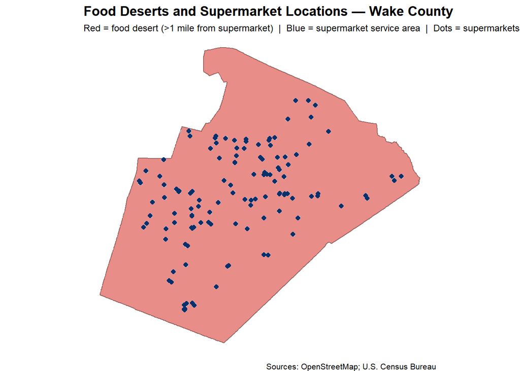

```r
# Clip layers to Wake County for a cleaner map
buffer_wake <- st_intersection(
  st_as_sf(data.frame(geometry = buffer_1mi), crs = NC_CRS),
  wake_boundary
)
desert_wake <- st_intersection(
  st_as_sf(data.frame(geometry = food_desert_area), crs = NC_CRS),
  wake_boundary
)
grocery_wake <- st_intersection(grocery, wake_boundary)

ggplot() +
  geom_sf(data = wake_boundary, fill = "white", color = "grey50", linewidth = 0.5) +
  geom_sf(data = buffer_wake,   fill = "#91bfdb", color = NA, alpha = 0.6) +
  geom_sf(data = desert_wake,   fill = "#d73027", color = NA, alpha = 0.55) +
  geom_sf(data = grocery_wake,  color = "#08306b", size = 1.8, shape = 16) +
  labs(
    title    = "Food Deserts and Supermarket Locations — Wake County",
    subtitle = "Red = food desert (>1 mile from supermarket)  |  Blue = supermarket service area  |  Dots = supermarkets",
    caption  = "Sources: OpenStreetMap; U.S. Census Bureau"
  ) +
  theme_void() +
  theme(plot.title    = element_text(face = "bold", size = 13),
        plot.subtitle = element_text(size = 9),
        plot.caption  = element_text(size = 8))
```

# 4 Identifying Food Desert Block Groups

## 4.1 Decision Rule

Many Census block groups will only *partially* fall within a food desert. A decision rule is required to classify each block group as a whole. Three common approaches are:

- **Centroid rule**: a block group is a food desert if its geographic centroid falls outside the 1-mile buffer.
- **Majority-area rule**: a block group is a food desert if more than 50% of its area is outside the buffer.
- **Any-overlap rule**: a block group is a food desert if *any* of its area is outside the buffer.

**We adopt the majority-area rule (>50% of area in food desert).** The centroid rule is simple but can misclassify large, irregularly shaped block groups whose centroid happens to land near a store even though most of the population lives far from one. The any-overlap rule over-classifies, flagging well-served suburban block groups that merely have a thin rural fringe beyond 1 mile. The majority-area rule captures the dominant character of each block group without either of these pitfalls, and it aligns with the fact that our demographic variables are attributed to the block group as a whole — not to sub-areas within it.

```r
# Total area of each block group (m²)
block_groups <- block_groups |>
  mutate(area_total = as.numeric(st_area(geometry)))

# Area of each block group that falls OUTSIDE the 1-mile buffer (= in food desert)
food_desert_sf <- st_as_sf(data.frame(geometry = food_desert_area), crs = NC_CRS)

intersection_desert <- st_intersection(
    block_groups |> select(GEOID),
    food_desert_sf
  ) |>
  mutate(area_desert = as.numeric(st_area(geometry))) |>
  st_drop_geometry() |>
  group_by(GEOID) |>
  summarise(area_desert = sum(area_desert), .groups = "drop")

block_groups <- block_groups |>
  left_join(intersection_desert, by = "GEOID") |>
  mutate(
    area_desert = replace_na(area_desert, 0),
    pct_desert  = area_desert / area_total,
    food_desert = pct_desert > 0.50   # majority-area rule
  )

# Refresh Wake-only subset
wake_bg <- block_groups |> filter(substr(GEOID, 1, 5) == "37183")

cat("Wake County block groups total:", nrow(wake_bg), "\n")
```

```
Wake County block groups total: 455
```

```r
cat("Classified as food desert:     ", sum(wake_bg$food_desert, na.rm = TRUE), "\n")
```

```
Classified as food desert:      446
```

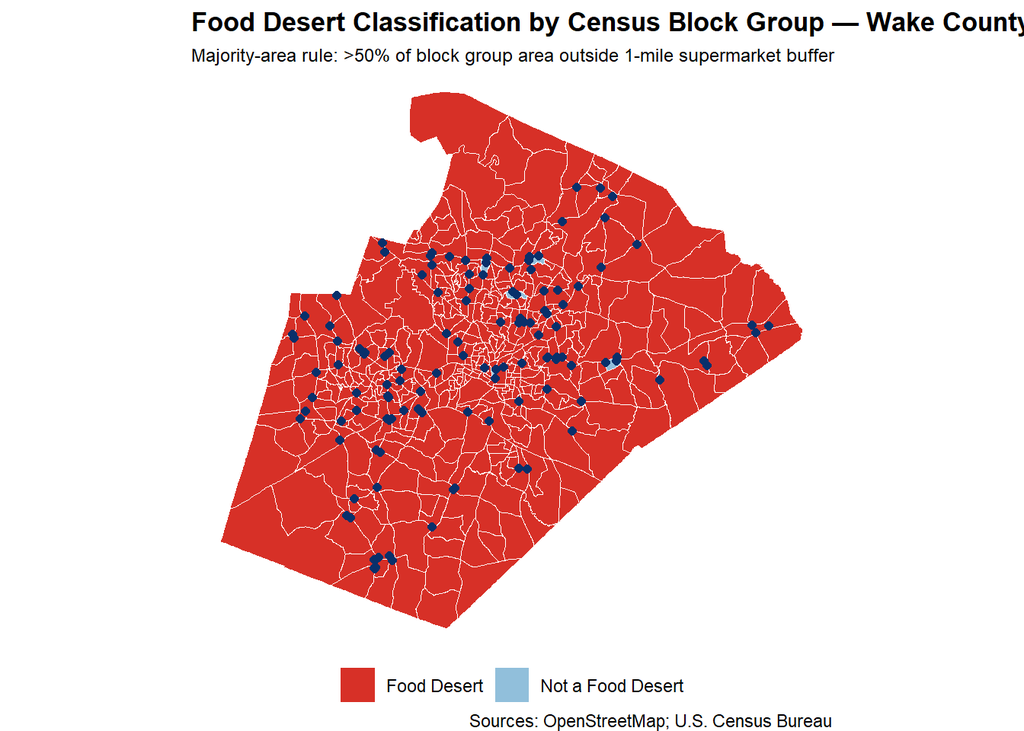

Figure 2: Wake County Census block groups classified as food deserts (red) or not (light blue) using the majority-area rule: a block group is a food desert when more than 50% of its area lies outside the 1-mile supermarket buffer. Blue dots mark supermarket locations.

```r
wake_bg_plot <- wake_bg |>
  mutate(Desert = if_else(food_desert, "Food Desert", "Not a Food Desert"))

ggplot() +
  geom_sf(data = wake_bg_plot, aes(fill = Desert),
          color = "white", linewidth = 0.1) +
  geom_sf(data = grocery_wake, color = "#08306b", size = 1.8, shape = 16) +
  scale_fill_manual(values = desert_colors, name = NULL) +
  labs(
    title    = "Food Desert Classification by Census Block Group — Wake County",
    subtitle = "Majority-area rule: >50% of block group area outside 1-mile supermarket buffer",
    caption  = "Sources: OpenStreetMap; U.S. Census Bureau"
  ) +
  theme_void() +
  theme(plot.title    = element_text(face = "bold", size = 13),
        plot.subtitle = element_text(size = 9),
        legend.position = "bottom")
```

# 5 Population Living in Food Deserts

```r
WAKE_TOTAL_POP <- 1069079   # provided in the assignment

pop_in_desert <- wake_bg |>
  st_drop_geometry() |>
  filter(food_desert) |>
  summarise(pop = sum(total_pop, na.rm = TRUE)) |>
  pull(pop)

pct_in_desert <- pop_in_desert / WAKE_TOTAL_POP * 100

cat(sprintf(
  "Population in food deserts : %s\n",   comma(pop_in_desert)))
```

```
Population in food deserts : 1,054,495
```

```r
cat(sprintf(
  "Wake County total population: %s\n",  comma(WAKE_TOTAL_POP)))
```

```
Wake County total population: 1,069,079
```

```r
cat(sprintf(
  "Percentage in food deserts  : %.1f%%\n", pct_in_desert))
```

```
Percentage in food deserts  : 98.6%
```

Approximately **1,054,495** Wake County residents — **98.6%** of the county’s 1,069,079 total residents — live in Census block groups classified as food deserts under the majority-area rule. This is a substantial share of the county population and warrants serious policy attention.

> **Methodological note**: Attributing the entire block group population to either “food desert” or “not food desert” introduces some imprecision — people living near a store at the edge of a majority-desert block group are counted as food desert residents. A more refined approach would weight population by the fraction of each block group in the food desert zone, but since Census demographic data are not available at the sub-block-group level, this whole-block-group approach is standard in applied food access research.